# Risk Factor Analysis

## Outcome Variable

**Outcome Variable:** wast_rec90d

## Predictor Variables

**Intervention Variable:** meducyrs

**Adjustment Set:**

- arm
- W_mage
- feducyrs
- hhwealth_quart
- W_mhtcm
- W_gagebrth
- W_birthwt
- W_birthlen
- single
- W_nrooms
- impsan
- delta_W_mage
- delta_feducyrs
- delta_hhwealth_quart
- delta_W_mhtcm
- delta_W_gagebrth
- delta_W_birthwt
- delta_W_birthlen
- delta_single
- delta_W_nrooms
- delta_impsan

## Stratifying Variables

The analysis was stratified on these variable(s):

- agecat
- studyid
- country

## Data Summary

| agecat | studyid | country | meducyrs | wast_rec90d | n_cell | n |
| --- | --- | --- | --- | --- | --- | --- |
| 0-24 months | ki0047075b-MAL-ED | BANGLADESH | High | 0 | 7 | 86 |
| 0-24 months | ki0047075b-MAL-ED | BANGLADESH | High | 1 | 20 | 86 |
| 0-24 months | ki0047075b-MAL-ED | BANGLADESH | Low | 0 | 10 | 86 |
| 0-24 months | ki0047075b-MAL-ED | BANGLADESH | Low | 1 | 22 | 86 |
| 0-24 months | ki0047075b-MAL-ED | BANGLADESH | Medium | 0 | 6 | 86 |
| 0-24 months | ki0047075b-MAL-ED | BANGLADESH | Medium | 1 | 21 | 86 |
| 0-24 months | ki0047075b-MAL-ED | BRAZIL | High | 0 | 0 | 23 |
| 0-24 months | ki0047075b-MAL-ED | BRAZIL | High | 1 | 3 | 23 |
| 0-24 months | ki0047075b-MAL-ED | BRAZIL | Low | 0 | 4 | 23 |
| 0-24 months | ki0047075b-MAL-ED | BRAZIL | Low | 1 | 6 | 23 |
| 0-24 months | ki0047075b-MAL-ED | BRAZIL | Medium | 0 | 2 | 23 |
| 0-24 months | ki0047075b-MAL-ED | BRAZIL | Medium | 1 | 8 | 23 |
| 0-24 months | ki0047075b-MAL-ED | INDIA | High | 0 | 12 | 153 |
| 0-24 months | ki0047075b-MAL-ED | INDIA | High | 1 | 19 | 153 |
| 0-24 months | ki0047075b-MAL-ED | INDIA | Low | 0 | 21 | 153 |
| 0-24 months | ki0047075b-MAL-ED | INDIA | Low | 1 | 42 | 153 |
| 0-24 months | ki0047075b-MAL-ED | INDIA | Medium | 0 | 25 | 153 |
| 0-24 months | ki0047075b-MAL-ED | INDIA | Medium | 1 | 34 | 153 |
| 0-24 months | ki0047075b-MAL-ED | NEPAL | High | 0 | 2 | 88 |
| 0-24 months | ki0047075b-MAL-ED | NEPAL | High | 1 | 14 | 88 |
| 0-24 months | ki0047075b-MAL-ED | NEPAL | Low | 0 | 5 | 88 |
| 0-24 months | ki0047075b-MAL-ED | NEPAL | Low | 1 | 28 | 88 |
| 0-24 months | ki0047075b-MAL-ED | NEPAL | Medium | 0 | 10 | 88 |
| 0-24 months | ki0047075b-MAL-ED | NEPAL | Medium | 1 | 29 | 88 |
| 0-24 months | ki0047075b-MAL-ED | PERU | High | 0 | 0 | 34 |
| 0-24 months | ki0047075b-MAL-ED | PERU | High | 1 | 3 | 34 |
| 0-24 months | ki0047075b-MAL-ED | PERU | Low | 0 | 2 | 34 |
| 0-24 months | ki0047075b-MAL-ED | PERU | Low | 1 | 14 | 34 |
| 0-24 months | ki0047075b-MAL-ED | PERU | Medium | 0 | 4 | 34 |
| 0-24 months | ki0047075b-MAL-ED | PERU | Medium | 1 | 11 | 34 |

[output cut: 438 more lines]

The following strata were considered:

- agecat: 0-24 months, studyid: ki0047075b-MAL-ED, country: BANGLADESH
- agecat: 0-24 months, studyid: ki0047075b-MAL-ED, country: BRAZIL
- agecat: 0-24 months, studyid: ki0047075b-MAL-ED, country: INDIA
- agecat: 0-24 months, studyid: ki0047075b-MAL-ED, country: NEPAL
- agecat: 0-24 months, studyid: ki0047075b-MAL-ED, country: PERU
- agecat: 0-24 months, studyid: ki0047075b-MAL-ED, country: SOUTH AFRICA
- agecat: 0-24 months, studyid: ki0047075b-MAL-ED, country: TANZANIA, UNITED REPUBLIC OF
- agecat: 0-24 months, studyid: ki1000108-CMC-V-BCS-2002, country: INDIA
- agecat: 0-24 months, studyid: ki1000108-IRC, country: INDIA
- agecat: 0-24 months, studyid: ki1000109-EE, country: PAKISTAN
- agecat: 0-24 months, studyid: ki1000304b-SAS-CompFeed, country: INDIA
- agecat: 0-24 months, studyid: ki1000304b-SAS-FoodSuppl, country: INDIA
- agecat: 0-24 months, studyid: ki1017093-NIH-Birth, country: BANGLADESH
- agecat: 0-24 months, studyid: ki1017093b-PROVIDE, country: BANGLADESH
- agecat: 0-24 months, studyid: ki1017093c-NIH-Crypto, country: BANGLADESH
- agecat: 0-24 months, studyid: ki1066203-TanzaniaChild2, country: TANZANIA, UNITED REPUBLIC OF
- agecat: 0-24 months, studyid: ki1112895-Guatemala BSC, country: GUATEMALA
- agecat: 0-24 months, studyid: ki1113344-GMS-Nepal, country: NEPAL
- agecat: 0-24 months, studyid: ki1119695-PROBIT, country: BELARUS
- agecat: 0-24 months, studyid: ki1126311-ZVITAMBO, country: ZIMBABWE
- agecat: 0-24 months, studyid: ki1135781-COHORTS, country: GUATEMALA
- agecat: 0-24 months, studyid: ki1135781-COHORTS, country: INDIA
- agecat: 0-24 months, studyid: ki1135781-COHORTS, country: PHILIPPINES
- agecat: 0-24 months, studyid: ki1148112-LCNI-5, country: MALAWI
- agecat: 0-24 months, studyid: kiGH5241-JiVitA-3, country: BANGLADESH
- agecat: 0-24 months, studyid: kiGH5241-JiVitA-4, country: BANGLADESH
- agecat: 0-6 months, studyid: ki0047075b-MAL-ED, country: BANGLADESH
- agecat: 0-6 months, studyid: ki0047075b-MAL-ED, country: BRAZIL
- agecat: 0-6 months, studyid: ki0047075b-MAL-ED, country: INDIA
- agecat: 0-6 months, studyid: ki0047075b-MAL-ED, country: NEPAL
- agecat: 0-6 months, studyid: ki0047075b-MAL-ED, country: PERU
- agecat: 0-6 months, studyid: ki0047075b-MAL-ED, country: SOUTH AFRICA
- agecat: 0-6 months, studyid: ki0047075b-MAL-ED, country: TANZANIA, UNITED REPUBLIC OF
- agecat: 0-6 months, studyid: ki1000108-CMC-V-BCS-2002, country: INDIA
- agecat: 0-6 months, studyid: ki1000108-IRC, country: INDIA
- agecat: 0-6 months, studyid: ki1000109-EE, country: PAKISTAN
- agecat: 0-6 months, studyid: ki1000304b-SAS-CompFeed, country: INDIA
- agecat: 0-6 months, studyid: ki1000304b-SAS-FoodSuppl, country: INDIA
- agecat: 0-6 months, studyid: ki1017093-NIH-Birth, country: BANGLADESH
- agecat: 0-6 months, studyid: ki1017093b-PROVIDE, country: BANGLADESH
- agecat: 0-6 months, studyid: ki1017093c-NIH-Crypto, country: BANGLADESH
- agecat: 0-6 months, studyid: ki1066203-TanzaniaChild2, country: TANZANIA, UNITED REPUBLIC OF
- agecat: 0-6 months, studyid: ki1112895-Guatemala BSC, country: GUATEMALA
- agecat: 0-6 months, studyid: ki1113344-GMS-Nepal, country: NEPAL
- agecat: 0-6 months, studyid: ki1119695-PROBIT, country: BELARUS
- agecat: 0-6 months, studyid: ki1126311-ZVITAMBO, country: ZIMBABWE
- agecat: 0-6 months, studyid: ki1135781-COHORTS, country: GUATEMALA
- agecat: 0-6 months, studyid: ki1135781-COHORTS, country: INDIA
- agecat: 0-6 months, studyid: ki1135781-COHORTS, country: PHILIPPINES
- agecat: 0-6 months, studyid: ki1148112-LCNI-5, country: MALAWI
- agecat: 0-6 months, studyid: kiGH5241-JiVitA-3, country: BANGLADESH
- agecat: 0-6 months, studyid: kiGH5241-JiVitA-4, country: BANGLADESH
- agecat: 6-24 months, studyid: ki0047075b-MAL-ED, country: BANGLADESH
- agecat: 6-24 months, studyid: ki0047075b-MAL-ED, country: BRAZIL
- agecat: 6-24 months, studyid: ki0047075b-MAL-ED, country: INDIA
- agecat: 6-24 months, studyid: ki0047075b-MAL-ED, country: NEPAL
- agecat: 6-24 months, studyid: ki0047075b-MAL-ED, country: PERU
- agecat: 6-24 months, studyid: ki0047075b-MAL-ED, country: SOUTH AFRICA
- agecat: 6-24 months, studyid: ki0047075b-MAL-ED, country: TANZANIA, UNITED REPUBLIC OF
- agecat: 6-24 months, studyid: ki1000108-CMC-V-BCS-2002, country: INDIA
- agecat: 6-24 months, studyid: ki1000108-IRC, country: INDIA
- agecat: 6-24 months, studyid: ki1000109-EE, country: PAKISTAN
- agecat: 6-24 months, studyid: ki1000304b-SAS-CompFeed, country: INDIA
- agecat: 6-24 months, studyid: ki1000304b-SAS-FoodSuppl, country: INDIA
- agecat: 6-24 months, studyid: ki1017093-NIH-Birth, country: BANGLADESH
- agecat: 6-24 months, studyid: ki1017093b-PROVIDE, country: BANGLADESH
- agecat: 6-24 months, studyid: ki1017093c-NIH-Crypto, country: BANGLADESH
- agecat: 6-24 months, studyid: ki1066203-TanzaniaChild2, country: TANZANIA, UNITED REPUBLIC OF
- agecat: 6-24 months, studyid: ki1112895-Guatemala BSC, country: GUATEMALA
- agecat: 6-24 months, studyid: ki1113344-GMS-Nepal, country: NEPAL
- agecat: 6-24 months, studyid: ki1119695-PROBIT, country: BELARUS
- agecat: 6-24 months, studyid: ki1126311-ZVITAMBO, country: ZIMBABWE
- agecat: 6-24 months, studyid: ki1135781-COHORTS, country: GUATEMALA
- agecat: 6-24 months, studyid: ki1135781-COHORTS, country: INDIA
- agecat: 6-24 months, studyid: ki1135781-COHORTS, country: PHILIPPINES
- agecat: 6-24 months, studyid: ki1148112-LCNI-5, country: MALAWI
- agecat: 6-24 months, studyid: kiGH5241-JiVitA-3, country: BANGLADESH
- agecat: 6-24 months, studyid: kiGH5241-JiVitA-4, country: BANGLADESH

### Dropped Strata

Some strata were dropped due to rare outcomes:

- agecat: 0-24 months, studyid: ki0047075b-MAL-ED, country: BRAZIL
- agecat: 0-24 months, studyid: ki0047075b-MAL-ED, country: NEPAL
- agecat: 0-24 months, studyid: ki0047075b-MAL-ED, country: PERU
- agecat: 0-24 months, studyid: ki0047075b-MAL-ED, country: SOUTH AFRICA
- agecat: 0-24 months, studyid: ki0047075b-MAL-ED, country: TANZANIA, UNITED REPUBLIC OF
- agecat: 0-24 months, studyid: ki1000109-EE, country: PAKISTAN
- agecat: 0-24 months, studyid: ki1000304b-SAS-FoodSuppl, country: INDIA
- agecat: 0-24 months, studyid: ki1112895-Guatemala BSC, country: GUATEMALA
- agecat: 0-24 months, studyid: ki1148112-LCNI-5, country: MALAWI
- agecat: 0-6 months, studyid: ki0047075b-MAL-ED, country: BANGLADESH
- agecat: 0-6 months, studyid: ki0047075b-MAL-ED, country: BRAZIL
- agecat: 0-6 months, studyid: ki0047075b-MAL-ED, country: NEPAL
- agecat: 0-6 months, studyid: ki0047075b-MAL-ED, country: PERU
- agecat: 0-6 months, studyid: ki0047075b-MAL-ED, country: SOUTH AFRICA
- agecat: 0-6 months, studyid: ki0047075b-MAL-ED, country: TANZANIA, UNITED REPUBLIC OF
- agecat: 0-6 months, studyid: ki1000109-EE, country: PAKISTAN
- agecat: 0-6 months, studyid: ki1000304b-SAS-FoodSuppl, country: INDIA
- agecat: 0-6 months, studyid: ki1066203-TanzaniaChild2, country: TANZANIA, UNITED REPUBLIC OF
- agecat: 0-6 months, studyid: ki1112895-Guatemala BSC, country: GUATEMALA
- agecat: 0-6 months, studyid: ki1148112-LCNI-5, country: MALAWI
- agecat: 0-6 months, studyid: kiGH5241-JiVitA-4, country: BANGLADESH
- agecat: 6-24 months, studyid: ki0047075b-MAL-ED, country: BANGLADESH
- agecat: 6-24 months, studyid: ki0047075b-MAL-ED, country: BRAZIL
- agecat: 6-24 months, studyid: ki0047075b-MAL-ED, country: NEPAL
- agecat: 6-24 months, studyid: ki0047075b-MAL-ED, country: PERU
- agecat: 6-24 months, studyid: ki0047075b-MAL-ED, country: SOUTH AFRICA
- agecat: 6-24 months, studyid: ki0047075b-MAL-ED, country: TANZANIA, UNITED REPUBLIC OF
- agecat: 6-24 months, studyid: ki1000109-EE, country: PAKISTAN
- agecat: 6-24 months, studyid: ki1000304b-SAS-FoodSuppl, country: INDIA
- agecat: 6-24 months, studyid: ki1017093c-NIH-Crypto, country: BANGLADESH
- agecat: 6-24 months, studyid: ki1112895-Guatemala BSC, country: GUATEMALA
- agecat: 6-24 months, studyid: ki1135781-COHORTS, country: GUATEMALA
- agecat: 6-24 months, studyid: ki1135781-COHORTS, country: INDIA
- agecat: 6-24 months, studyid: ki1148112-LCNI-5, country: MALAWI
- agecat: 6-24 months, studyid: kiGH5241-JiVitA-3, country: BANGLADESH
- agecat: 6-24 months, studyid: kiGH5241-JiVitA-4, country: BANGLADESH

## Methods Detail

We’re interested in the causal parameters $E[Y_a]$ for all values of $a \in \mathcal{A}$. These parameters represent the mean outcome if, possibly contrary to fact, we intervened to set all units to have $A=a$. Under the randomization and positivity assumptions, these are identified by the statistical parameters $\psi_a=E_W[E_{Y|A,W}(Y|A=a,W)]$. In addition, we’re interested in the mean of $Y$, $E[Y]$ under no intervention (the observed mean). We will estimate these parameters by using SuperLearner to fit the relevant likelihood factors – $E_{Y|A,W}(Y|A=a,W)$ and $p(A=a|W)$, and then updating our likelihood fit using a joint TMLE.

For unadjusted analyses ($W=\{\}$), initial likelihoods were estimated using Lrnr_glm to estimate the simple $E(Y|A)$ and Lrnr_mean to estimate $p(A)$. For adjusted analyses, a small library containing Lrnr_glmnet, Lrnr_xgboost, and Lrnr_mean was used.

Having estimated these parameters, we will then use the delta method to estimate relative risks and attributable risks relative to a prespecified baseline level of $A$.

# Results Detail

## Results Plots

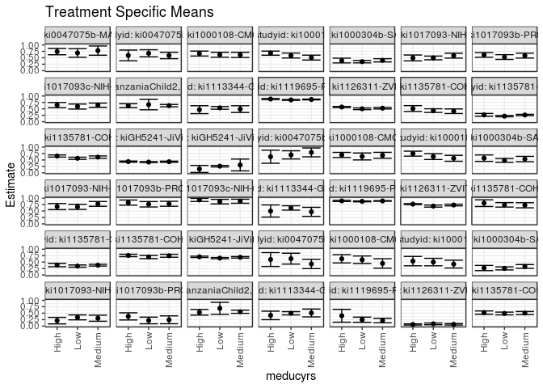

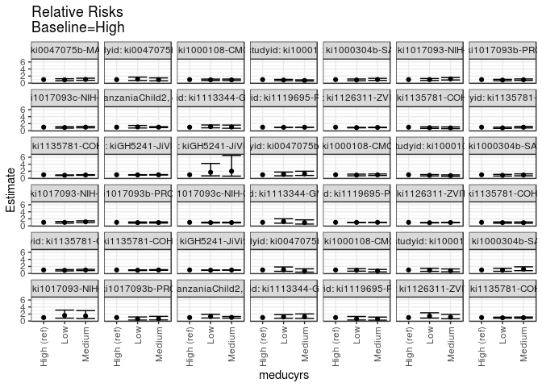

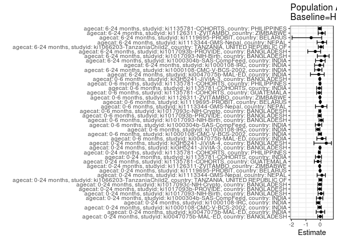

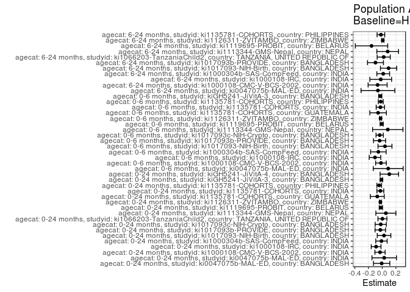

## Results Table

### Parameter: TSM

| agecat | studyid | country | intervention_level | baseline_level | estimate | ci_lower | ci_upper |
| --- | --- | --- | --- | --- | --- | --- | --- |
| 0-24 months | ki0047075b-MAL-ED | BANGLADESH | High | NA | 0.7407407 | 0.6174221 | 0.8640594 |
| 0-24 months | ki0047075b-MAL-ED | BANGLADESH | Low | NA | 0.6875000 | 0.5204085 | 0.8545915 |
| 0-24 months | ki0047075b-MAL-ED | BANGLADESH | Medium | NA | 0.7777778 | 0.5988250 | 0.9567305 |
| 0-24 months | ki0047075b-MAL-ED | INDIA | High | NA | 0.5919339 | 0.3847109 | 0.7991569 |
| 0-24 months | ki0047075b-MAL-ED | INDIA | Low | NA | 0.6739086 | 0.5364076 | 0.8114096 |
| 0-24 months | ki0047075b-MAL-ED | INDIA | Medium | NA | 0.5891862 | 0.4645002 | 0.7138723 |
| 0-24 months | ki1000108-CMC-V-BCS-2002 | INDIA | High | NA | 0.6639654 | 0.5680025 | 0.7599283 |
| 0-24 months | ki1000108-CMC-V-BCS-2002 | INDIA | Low | NA | 0.6179527 | 0.5226330 | 0.7132725 |
| 0-24 months | ki1000108-CMC-V-BCS-2002 | INDIA | Medium | NA | 0.6122648 | 0.5112638 | 0.7132659 |
| 0-24 months | ki1000108-IRC | INDIA | High | NA | 0.6791935 | 0.5989009 | 0.7594862 |
| 0-24 months | ki1000108-IRC | INDIA | Low | NA | 0.5873292 | 0.4913525 | 0.6833060 |
| 0-24 months | ki1000108-IRC | INDIA | Medium | NA | 0.5076825 | 0.4131486 | 0.6022164 |
| 0-24 months | ki1000304b-SAS-CompFeed | INDIA | High | NA | 0.3920961 | 0.3002234 | 0.4839689 |
| 0-24 months | ki1000304b-SAS-CompFeed | INDIA | Low | NA | 0.3498383 | 0.3021907 | 0.3974858 |
| 0-24 months | ki1000304b-SAS-CompFeed | INDIA | Medium | NA | 0.4016146 | 0.3395718 | 0.4636574 |
| 0-24 months | ki1017093-NIH-Birth | BANGLADESH | High | NA | 0.4936217 | 0.3803772 | 0.6068662 |
| 0-24 months | ki1017093-NIH-Birth | BANGLADESH | Low | NA | 0.4940662 | 0.4215145 | 0.5666180 |
| 0-24 months | ki1017093-NIH-Birth | BANGLADESH | Medium | NA | 0.5826512 | 0.4873809 | 0.6779215 |
| 0-24 months | ki1017093b-PROVIDE | BANGLADESH | High | NA | 0.6110739 | 0.5201333 | 0.7020146 |
| 0-24 months | ki1017093b-PROVIDE | BANGLADESH | Low | NA | 0.5280790 | 0.4361381 | 0.6200199 |
| 0-24 months | ki1017093b-PROVIDE | BANGLADESH | Medium | NA | 0.5837369 | 0.4881758 | 0.6792981 |
| 0-24 months | ki1017093c-NIH-Crypto | BANGLADESH | High | NA | 0.6453553 | 0.5446033 | 0.7461073 |
| 0-24 months | ki1017093c-NIH-Crypto | BANGLADESH | Low | NA | 0.5904007 | 0.4922359 | 0.6885655 |
| 0-24 months | ki1017093c-NIH-Crypto | BANGLADESH | Medium | NA | 0.6422944 | 0.5606514 | 0.7239374 |
| 0-24 months | ki1066203-TanzaniaChild2 | TANZANIA, UNITED REPUBLIC OF | High | NA | 0.6235955 | 0.5481204 | 0.6990706 |
| 0-24 months | ki1066203-TanzaniaChild2 | TANZANIA, UNITED REPUBLIC OF | Low | NA | 0.6666667 | 0.4628279 | 0.8705055 |
| 0-24 months | ki1066203-TanzaniaChild2 | TANZANIA, UNITED REPUBLIC OF | Medium | NA | 0.6254902 | 0.5809696 | 0.6700108 |
| 0-24 months | ki1113344-GMS-Nepal | NEPAL | High | NA | 0.4679583 | 0.3148606 | 0.6210559 |
| 0-24 months | ki1113344-GMS-Nepal | NEPAL | Low | NA | 0.5381491 | 0.4863636 | 0.5899346 |
| 0-24 months | ki1113344-GMS-Nepal | NEPAL | Medium | NA | 0.4901878 | 0.3602961 | 0.6200795 |

[output cut: 96 more lines]

### Parameter: E(Y)

| agecat | studyid | country | intervention_level | baseline_level | estimate | ci_lower | ci_upper |
| --- | --- | --- | --- | --- | --- | --- | --- |
| 0-24 months | ki0047075b-MAL-ED | BANGLADESH | NA | NA | 0.7325581 | 0.6399608 | 0.8251555 |
| 0-24 months | ki0047075b-MAL-ED | INDIA | NA | NA | 0.6209150 | 0.5357837 | 0.7060464 |
| 0-24 months | ki1000108-CMC-V-BCS-2002 | INDIA | NA | NA | 0.6319018 | 0.5759256 | 0.6878781 |
| 0-24 months | ki1000108-IRC | INDIA | NA | NA | 0.5898734 | 0.5376978 | 0.6420491 |
| 0-24 months | ki1000304b-SAS-CompFeed | INDIA | NA | NA | 0.3808354 | 0.3457640 | 0.4159068 |
| 0-24 months | ki1017093-NIH-Birth | BANGLADESH | NA | NA | 0.5201900 | 0.4695846 | 0.5707955 |
| 0-24 months | ki1017093b-PROVIDE | BANGLADESH | NA | NA | 0.5830619 | 0.5262762 | 0.6398476 |
| 0-24 months | ki1017093c-NIH-Crypto | BANGLADESH | NA | NA | 0.6237942 | 0.5698223 | 0.6777662 |
| 0-24 months | ki1066203-TanzaniaChild2 | TANZANIA, UNITED REPUBLIC OF | NA | NA | 0.6264045 | 0.5887191 | 0.6640899 |
| 0-24 months | ki1113344-GMS-Nepal | NEPAL | NA | NA | 0.5215054 | 0.4764383 | 0.5665724 |
| 0-24 months | ki1119695-PROBIT | BELARUS | NA | NA | 0.8612051 | 0.8511051 | 0.8713052 |
| 0-24 months | ki1126311-ZVITAMBO | ZIMBABWE | NA | NA | 0.5438498 | 0.5273663 | 0.5603333 |
| 0-24 months | ki1135781-COHORTS | GUATEMALA | NA | NA | 0.4403183 | 0.3884516 | 0.4921850 |
| 0-24 months | ki1135781-COHORTS | INDIA | NA | NA | 0.2397357 | 0.2214428 | 0.2580286 |
| 0-24 months | ki1135781-COHORTS | PHILIPPINES | NA | NA | 0.6068680 | 0.5823645 | 0.6313715 |
| 0-24 months | kiGH5241-JiVitA-3 | BANGLADESH | NA | NA | 0.4226041 | 0.4114768 | 0.4337314 |
| 0-24 months | kiGH5241-JiVitA-4 | BANGLADESH | NA | NA | 0.2552719 | 0.2263808 | 0.2841631 |
| 0-6 months | ki0047075b-MAL-ED | INDIA | NA | NA | 0.7123288 | 0.6046595 | 0.8199981 |
| 0-6 months | ki1000108-CMC-V-BCS-2002 | INDIA | NA | NA | 0.6748768 | 0.6092233 | 0.7405304 |
| 0-6 months | ki1000108-IRC | INDIA | NA | NA | 0.6375000 | 0.5751450 | 0.6998550 |
| 0-6 months | ki1000304b-SAS-CompFeed | INDIA | NA | NA | 0.5131965 | 0.4596632 | 0.5667297 |
| 0-6 months | ki1017093-NIH-Birth | BANGLADESH | NA | NA | 0.7130045 | 0.6535890 | 0.7724200 |
| 0-6 months | ki1017093b-PROVIDE | BANGLADESH | NA | NA | 0.7880435 | 0.7295878 | 0.8464992 |
| 0-6 months | ki1017093c-NIH-Crypto | BANGLADESH | NA | NA | 0.8939394 | 0.8505280 | 0.9373508 |
| 0-6 months | ki1113344-GMS-Nepal | NEPAL | NA | NA | 0.5810056 | 0.5082784 | 0.6537327 |
| 0-6 months | ki1119695-PROBIT | BELARUS | NA | NA | 0.8855266 | 0.8758983 | 0.8951550 |
| 0-6 months | ki1126311-ZVITAMBO | ZIMBABWE | NA | NA | 0.7432325 | 0.7261601 | 0.7603048 |
| 0-6 months | ki1135781-COHORTS | GUATEMALA | NA | NA | 0.7452830 | 0.6866274 | 0.8039386 |
| 0-6 months | ki1135781-COHORTS | INDIA | NA | NA | 0.3595188 | 0.3344897 | 0.3845478 |
| 0-6 months | ki1135781-COHORTS | PHILIPPINES | NA | NA | 0.7367021 | 0.7051294 | 0.7682749 |
| 0-6 months | kiGH5241-JiVitA-3 | BANGLADESH | NA | NA | 0.6754701 | 0.6621313 | 0.6888089 |
| 6-24 months | ki0047075b-MAL-ED | INDIA | NA | NA | 0.5375000 | 0.4127227 | 0.6622773 |
| 6-24 months | ki1000108-CMC-V-BCS-2002 | INDIA | NA | NA | 0.5609756 | 0.4682842 | 0.6536670 |
| 6-24 months | ki1000108-IRC | INDIA | NA | NA | 0.5161290 | 0.4322562 | 0.6000019 |
| 6-24 months | ki1000304b-SAS-CompFeed | INDIA | NA | NA | 0.2854123 | 0.2436284 | 0.3271961 |
| 6-24 months | ki1017093-NIH-Birth | BANGLADESH | NA | NA | 0.3030303 | 0.2377927 | 0.3682679 |
| 6-24 months | ki1017093b-PROVIDE | BANGLADESH | NA | NA | 0.2764228 | 0.1950773 | 0.3577682 |
| 6-24 months | ki1066203-TanzaniaChild2 | TANZANIA, UNITED REPUBLIC OF | NA | NA | 0.5564516 | 0.5041613 | 0.6087419 |
| 6-24 months | ki1113344-GMS-Nepal | NEPAL | NA | NA | 0.4934037 | 0.4386266 | 0.5481808 |
| 6-24 months | ki1119695-PROBIT | BELARUS | NA | NA | 0.2440476 | 0.1791134 | 0.3089818 |
| 6-24 months | ki1126311-ZVITAMBO | ZIMBABWE | NA | NA | 0.0700095 | 0.0547600 | 0.0852589 |
| 6-24 months | ki1135781-COHORTS | PHILIPPINES | NA | NA | 0.5026681 | 0.4688378 | 0.5364984 |

### Parameter: RR

| agecat | studyid | country | intervention_level | baseline_level | estimate | ci_lower | ci_upper |
| --- | --- | --- | --- | --- | --- | --- | --- |
| 0-24 months | ki0047075b-MAL-ED | BANGLADESH | High | High | 1.0000000 | 1.0000000 | 1.0000000 |
| 0-24 months | ki0047075b-MAL-ED | BANGLADESH | Low | High | 0.9281250 | 0.6910533 | 1.2465262 |
| 0-24 months | ki0047075b-MAL-ED | BANGLADESH | Medium | High | 1.0500000 | 0.7907151 | 1.3943075 |
| 0-24 months | ki0047075b-MAL-ED | INDIA | High | High | 1.0000000 | 1.0000000 | 1.0000000 |
| 0-24 months | ki0047075b-MAL-ED | INDIA | Low | High | 1.1384861 | 0.7592806 | 1.7070774 |
| 0-24 months | ki0047075b-MAL-ED | INDIA | Medium | High | 0.9953581 | 0.6669481 | 1.4854796 |
| 0-24 months | ki1000108-CMC-V-BCS-2002 | INDIA | High | High | 1.0000000 | 1.0000000 | 1.0000000 |
| 0-24 months | ki1000108-CMC-V-BCS-2002 | INDIA | Low | High | 0.9307002 | 0.7533678 | 1.1497740 |
| 0-24 months | ki1000108-CMC-V-BCS-2002 | INDIA | Medium | High | 0.9221336 | 0.7404171 | 1.1484477 |
| 0-24 months | ki1000108-IRC | INDIA | High | High | 1.0000000 | 1.0000000 | 1.0000000 |
| 0-24 months | ki1000108-IRC | INDIA | Low | High | 0.8647450 | 0.7069073 | 1.0578246 |
| 0-24 months | ki1000108-IRC | INDIA | Medium | High | 0.7474784 | 0.5994778 | 0.9320177 |
| 0-24 months | ki1000304b-SAS-CompFeed | INDIA | High | High | 1.0000000 | 1.0000000 | 1.0000000 |
| 0-24 months | ki1000304b-SAS-CompFeed | INDIA | Low | High | 0.8922257 | 0.6816069 | 1.1679266 |
| 0-24 months | ki1000304b-SAS-CompFeed | INDIA | Medium | High | 1.0242758 | 0.7757688 | 1.3523885 |
| 0-24 months | ki1017093-NIH-Birth | BANGLADESH | High | High | 1.0000000 | 1.0000000 | 1.0000000 |
| 0-24 months | ki1017093-NIH-Birth | BANGLADESH | Low | High | 1.0009005 | 0.7626013 | 1.3136638 |
| 0-24 months | ki1017093-NIH-Birth | BANGLADESH | Medium | High | 1.1803597 | 0.8911931 | 1.5633527 |
| 0-24 months | ki1017093b-PROVIDE | BANGLADESH | High | High | 1.0000000 | 1.0000000 | 1.0000000 |
| 0-24 months | ki1017093b-PROVIDE | BANGLADESH | Low | High | 0.8641819 | 0.6914055 | 1.0801336 |
| 0-24 months | ki1017093b-PROVIDE | BANGLADESH | Medium | High | 0.9552640 | 0.7704734 | 1.1843750 |
| 0-24 months | ki1017093c-NIH-Crypto | BANGLADESH | High | High | 1.0000000 | 1.0000000 | 1.0000000 |
| 0-24 months | ki1017093c-NIH-Crypto | BANGLADESH | Low | High | 0.9148460 | 0.7287278 | 1.1484991 |
| 0-24 months | ki1017093c-NIH-Crypto | BANGLADESH | Medium | High | 0.9952571 | 0.8159416 | 1.2139799 |
| 0-24 months | ki1066203-TanzaniaChild2 | TANZANIA, UNITED REPUBLIC OF | High | High | 1.0000000 | 1.0000000 | 1.0000000 |
| 0-24 months | ki1066203-TanzaniaChild2 | TANZANIA, UNITED REPUBLIC OF | Low | High | 1.0690691 | 0.7694770 | 1.4853058 |
| 0-24 months | ki1066203-TanzaniaChild2 | TANZANIA, UNITED REPUBLIC OF | Medium | High | 1.0030383 | 0.8716480 | 1.1542341 |
| 0-24 months | ki1113344-GMS-Nepal | NEPAL | High | High | 1.0000000 | 1.0000000 | 1.0000000 |
| 0-24 months | ki1113344-GMS-Nepal | NEPAL | Low | High | 1.1499938 | 0.8177096 | 1.6173047 |
| 0-24 months | ki1113344-GMS-Nepal | NEPAL | Medium | High | 1.0475032 | 0.6874655 | 1.5960989 |

[output cut: 96 more lines]

### Parameter: PAR

| agecat | studyid | country | intervention_level | baseline_level | estimate | ci_lower | ci_upper |
| --- | --- | --- | --- | --- | --- | --- | --- |
| 0-24 months | ki0047075b-MAL-ED | BANGLADESH | High | NA | -0.0081826 | -0.1272337 | 0.1108685 |
| 0-24 months | ki0047075b-MAL-ED | INDIA | High | NA | 0.0289811 | -0.1500145 | 0.2079768 |
| 0-24 months | ki1000108-CMC-V-BCS-2002 | INDIA | High | NA | -0.0320636 | -0.1067584 | 0.0426313 |
| 0-24 months | ki1000108-IRC | INDIA | High | NA | -0.0893201 | -0.1604003 | -0.0182400 |
| 0-24 months | ki1000304b-SAS-CompFeed | INDIA | High | NA | -0.0112608 | -0.0943220 | 0.0718005 |
| 0-24 months | ki1017093-NIH-Birth | BANGLADESH | High | NA | 0.0265683 | -0.0724976 | 0.1256343 |
| 0-24 months | ki1017093b-PROVIDE | BANGLADESH | High | NA | -0.0280120 | -0.1048526 | 0.0488286 |
| 0-24 months | ki1017093c-NIH-Crypto | BANGLADESH | High | NA | -0.0215611 | -0.1032706 | 0.0601484 |
| 0-24 months | ki1066203-TanzaniaChild2 | TANZANIA, UNITED REPUBLIC OF | High | NA | 0.0028090 | -0.0625216 | 0.0681396 |
| 0-24 months | ki1113344-GMS-Nepal | NEPAL | High | NA | 0.0535471 | -0.0926867 | 0.1997809 |
| 0-24 months | ki1119695-PROBIT | BELARUS | High | NA | -0.0196510 | -0.0437922 | 0.0044902 |
| 0-24 months | ki1126311-ZVITAMBO | ZIMBABWE | High | NA | -0.0270113 | -0.0408429 | -0.0131797 |
| 0-24 months | ki1135781-COHORTS | GUATEMALA | High | NA | -0.0717189 | -0.1730239 | 0.0295861 |
| 0-24 months | ki1135781-COHORTS | INDIA | High | NA | -0.0272159 | -0.0773768 | 0.0229451 |
| 0-24 months | ki1135781-COHORTS | PHILIPPINES | High | NA | -0.0441810 | -0.0782530 | -0.0101089 |
| 0-24 months | kiGH5241-JiVitA-3 | BANGLADESH | High | NA | -0.0116479 | -0.0303363 | 0.0070405 |
| 0-24 months | kiGH5241-JiVitA-4 | BANGLADESH | High | NA | 0.1037568 | -0.0310620 | 0.2385756 |
| 0-6 months | ki0047075b-MAL-ED | INDIA | High | NA | 0.0873288 | -0.1305883 | 0.3052459 |
| 0-6 months | ki1000108-CMC-V-BCS-2002 | INDIA | High | NA | -0.0181719 | -0.0959031 | 0.0595593 |
| 0-6 months | ki1000108-IRC | INDIA | High | NA | -0.1056261 | -0.1897439 | -0.0215084 |
| 0-6 months | ki1000304b-SAS-CompFeed | INDIA | High | NA | -0.0559220 | -0.1688856 | 0.0570416 |
| 0-6 months | ki1017093-NIH-Birth | BANGLADESH | High | NA | 0.0401740 | -0.0617031 | 0.1420510 |
| 0-6 months | ki1017093b-PROVIDE | BANGLADESH | High | NA | -0.0388796 | -0.1271652 | 0.0494060 |
| 0-6 months | ki1017093c-NIH-Crypto | BANGLADESH | High | NA | -0.0366162 | -0.0900005 | 0.0167682 |
| 0-6 months | ki1113344-GMS-Nepal | NEPAL | High | NA | 0.0810056 | -0.1406447 | 0.3026559 |
| 0-6 months | ki1119695-PROBIT | BELARUS | High | NA | -0.0079101 | -0.0307164 | 0.0148962 |
| 0-6 months | ki1126311-ZVITAMBO | ZIMBABWE | High | NA | -0.0241832 | -0.0387073 | -0.0096590 |
| 0-6 months | ki1135781-COHORTS | GUATEMALA | High | NA | -0.0602725 | -0.1812521 | 0.0607071 |
| 0-6 months | ki1135781-COHORTS | INDIA | High | NA | -0.0268359 | -0.0879433 | 0.0342714 |
| 0-6 months | ki1135781-COHORTS | PHILIPPINES | High | NA | -0.0212871 | -0.0570953 | 0.0145212 |
| 0-6 months | kiGH5241-JiVitA-3 | BANGLADESH | High | NA | -0.0293211 | -0.0520780 | -0.0065642 |
| 6-24 months | ki0047075b-MAL-ED | INDIA | High | NA | -0.0625000 | -0.3091435 | 0.1841435 |
| 6-24 months | ki1000108-CMC-V-BCS-2002 | INDIA | High | NA | -0.0670746 | -0.2058201 | 0.0716709 |
| 6-24 months | ki1000108-IRC | INDIA | High | NA | -0.0217634 | -0.1804938 | 0.1369669 |
| 6-24 months | ki1000304b-SAS-CompFeed | INDIA | High | NA | 0.0148816 | -0.0781485 | 0.1079117 |
| 6-24 months | ki1017093-NIH-Birth | BANGLADESH | High | NA | 0.0925040 | -0.0259710 | 0.2109790 |
| 6-24 months | ki1017093b-PROVIDE | BANGLADESH | High | NA | -0.0985772 | -0.2149020 | 0.0177476 |
| 6-24 months | ki1066203-TanzaniaChild2 | TANZANIA, UNITED REPUBLIC OF | High | NA | 0.0215679 | -0.0739879 | 0.1171237 |
| 6-24 months | ki1113344-GMS-Nepal | NEPAL | High | NA | 0.0797919 | -0.0785310 | 0.2381149 |
| 6-24 months | ki1119695-PROBIT | BELARUS | High | NA | -0.1559524 | -0.3917880 | 0.0798833 |
| 6-24 months | ki1126311-ZVITAMBO | ZIMBABWE | High | NA | 0.0083217 | -0.0084141 | 0.0250576 |
| 6-24 months | ki1135781-COHORTS | PHILIPPINES | High | NA | -0.0191340 | -0.0749406 | 0.0366726 |

### Parameter: PAF

| agecat | studyid | country | intervention_level | baseline_level | estimate | ci_lower | ci_upper |
| --- | --- | --- | --- | --- | --- | --- | --- |
| 0-24 months | ki0047075b-MAL-ED | BANGLADESH | High | NA | -0.0111699 | -0.1880458 | 0.1393728 |
| 0-24 months | ki0047075b-MAL-ED | INDIA | High | NA | 0.0466749 | -0.2910686 | 0.2960646 |
| 0-24 months | ki1000108-CMC-V-BCS-2002 | INDIA | High | NA | -0.0507414 | -0.1756503 | 0.0608964 |
| 0-24 months | ki1000108-IRC | INDIA | High | NA | -0.1514225 | -0.2819034 | -0.0342229 |
| 0-24 months | ki1000304b-SAS-CompFeed | INDIA | High | NA | -0.0295686 | -0.2723352 | 0.1668772 |
| 0-24 months | ki1017093-NIH-Birth | BANGLADESH | High | NA | 0.0510743 | -0.1601741 | 0.2238578 |
| 0-24 months | ki1017093b-PROVIDE | BANGLADESH | High | NA | -0.0480430 | -0.1890909 | 0.0762741 |
| 0-24 months | ki1017093c-NIH-Crypto | BANGLADESH | High | NA | -0.0345644 | -0.1740285 | 0.0883326 |
| 0-24 months | ki1066203-TanzaniaChild2 | TANZANIA, UNITED REPUBLIC OF | High | NA | 0.0044843 | -0.1054703 | 0.1035023 |
| 0-24 months | ki1113344-GMS-Nepal | NEPAL | High | NA | 0.1026780 | -0.2266991 | 0.3436150 |
| 0-24 months | ki1119695-PROBIT | BELARUS | High | NA | -0.0228180 | -0.0512524 | 0.0048473 |
| 0-24 months | ki1126311-ZVITAMBO | ZIMBABWE | High | NA | -0.0496668 | -0.0755020 | -0.0244522 |
| 0-24 months | ki1135781-COHORTS | GUATEMALA | High | NA | -0.1628797 | -0.4183617 | 0.0465837 |
| 0-24 months | ki1135781-COHORTS | INDIA | High | NA | -0.1135245 | -0.3437562 | 0.0772606 |
| 0-24 months | ki1135781-COHORTS | PHILIPPINES | High | NA | -0.0728016 | -0.1305102 | -0.0180389 |
| 0-24 months | kiGH5241-JiVitA-3 | BANGLADESH | High | NA | -0.0275622 | -0.0727586 | 0.0157299 |
| 0-24 months | kiGH5241-JiVitA-4 | BANGLADESH | High | NA | 0.4064559 | -0.4453381 | 0.7562545 |
| 0-6 months | ki0047075b-MAL-ED | INDIA | High | NA | 0.1225962 | -0.2469266 | 0.3826120 |
| 0-6 months | ki1000108-CMC-V-BCS-2002 | INDIA | High | NA | -0.0269262 | -0.1489042 | 0.0821015 |
| 0-6 months | ki1000108-IRC | INDIA | High | NA | -0.1656881 | -0.3093629 | -0.0377785 |
| 0-6 months | ki1000304b-SAS-CompFeed | INDIA | High | NA | -0.1089680 | -0.3528670 | 0.0909601 |
| 0-6 months | ki1017093-NIH-Birth | BANGLADESH | High | NA | 0.0563446 | -0.0980694 | 0.1890444 |
| 0-6 months | ki1017093b-PROVIDE | BANGLADESH | High | NA | -0.0493369 | -0.1680752 | 0.0573313 |
| 0-6 months | ki1017093c-NIH-Crypto | BANGLADESH | High | NA | -0.0409605 | -0.1030051 | 0.0175941 |
| 0-6 months | ki1113344-GMS-Nepal | NEPAL | High | NA | 0.1394231 | -0.3416494 | 0.4479984 |
| 0-6 months | ki1119695-PROBIT | BELARUS | High | NA | -0.0089326 | -0.0350215 | 0.0164987 |
| 0-6 months | ki1126311-ZVITAMBO | ZIMBABWE | High | NA | -0.0325378 | -0.0523519 | -0.0130968 |
| 0-6 months | ki1135781-COHORTS | GUATEMALA | High | NA | -0.0808720 | -0.2567513 | 0.0703934 |
| 0-6 months | ki1135781-COHORTS | INDIA | High | NA | -0.0746440 | -0.2591263 | 0.0828087 |
| 0-6 months | ki1135781-COHORTS | PHILIPPINES | High | NA | -0.0288951 | -0.0787264 | 0.0186343 |
| 0-6 months | kiGH5241-JiVitA-3 | BANGLADESH | High | NA | -0.0434084 | -0.0776931 | -0.0102145 |
| 6-24 months | ki0047075b-MAL-ED | INDIA | High | NA | -0.1162791 | -0.6878499 | 0.2617359 |
| 6-24 months | ki1000108-CMC-V-BCS-2002 | INDIA | High | NA | -0.1195677 | -0.3989584 | 0.1040250 |
| 6-24 months | ki1000108-IRC | INDIA | High | NA | -0.0421667 | -0.3997236 | 0.2240530 |
| 6-24 months | ki1000304b-SAS-CompFeed | INDIA | High | NA | 0.0521408 | -0.3366936 | 0.3278662 |
| 6-24 months | ki1017093-NIH-Birth | BANGLADESH | High | NA | 0.3052632 | -0.2119312 | 0.6017437 |
| 6-24 months | ki1017093b-PROVIDE | BANGLADESH | High | NA | -0.3566176 | -0.8742527 | 0.0180559 |
| 6-24 months | ki1066203-TanzaniaChild2 | TANZANIA, UNITED REPUBLIC OF | High | NA | 0.0387597 | -0.1493241 | 0.1960641 |
| 6-24 months | ki1113344-GMS-Nepal | NEPAL | High | NA | 0.1617174 | -0.2287036 | 0.4280819 |
| 6-24 months | ki1119695-PROBIT | BELARUS | High | NA | -0.6390244 | -1.9550955 | 0.0909258 |
| 6-24 months | ki1126311-ZVITAMBO | ZIMBABWE | High | NA | 0.1188660 | -0.1535759 | 0.3269648 |
| 6-24 months | ki1135781-COHORTS | PHILIPPINES | High | NA | -0.0380648 | -0.1553465 | 0.0673114 |